# Soluzione - Homework 3

Alessio Matessi

2026-05-18

# Esercizio 1

Costruisci una funzione `decompose` che ha come input un insieme di dati divisi in gruppi (bastano una variabile di tipo numeric ed una di tipo factor) e calcola i seguenti punti:

1. La devianza entro i gruppi $DEV_{within}$, la devianza tra i gruppi $DEV_{between}$ e la devianza totale $DEV_{tot}$;
2. Il coefficiente $\eta^2$.

Applica poi la funzione così costruita sul dataset `iris`, disponibile in `R`, e confronta i risultati con quellio ottenuti mediante la funzione `aov`.

## ✏️ Svolgimento

### 🔹 Punto a)

```r
# Funzione per il calcolo delle devianze
decompose <- function(y, g)
{
  m_tot <- mean(y)
  m_g <- tapply(y, g, mean)
  n_g <- tapply(y, g, length)

  dev_tot <- sum((y - m_tot)^2)
  dev_bet <- sum(n_g * (m_g - m_tot)^2)
  dev_wit <- dev_tot - dev_bet

  res <- c(dev_wit, dev_bet, dev_tot)
  names(res) <- c("DEV_within", "DEV_between", "DEV_tot")
  return(round(res, 3))
}

# Applicazione al dataset IRIS
decompose(iris$Sepal.Length, iris$Species)
```

```
##  DEV_within DEV_between     DEV_tot
##      38.956      63.212     102.168
```

## 💥 Risposta

La funzione `decompose` restituisce i valori delle tre devianze:

Questi valori indicano come la variabilità totale della lunghezza del sepalo sia ripartita tra la differenza tra le medie delle specie (devianza tra i gruppi) e la variabilità interna alle specie stesse (devianza entro i gruppi).  
La devianza tra i gruppi è molto più grande di quella entro i gruppi, suggerendo che la specie spiega gran parte della variabilità osservata.

### 🔹 Punto b)

```r
# Funzione completa con il calcolo di eta_2
decompose <- function(y, g)
{
  m_tot <- mean(y)
  m_g <- tapply(y, g, mean)
  n_g <- tapply(y, g, length)

  dev_tot <- sum((y - m_tot)^2)
  dev_bet <- sum(n_g * (m_g - m_tot)^2)
  dev_wit <- dev_tot - dev_bet

  # Calcolo del coefficiente eta quadro
  eta_2 <- dev_bet / dev_tot

  res <- c(dev_wit, dev_bet, dev_tot, eta_2)
  names(res) <- c("DEV_within", "DEV_between", "DEV_tot", "eta_2")
  return(round(res, 3))
}

# Applicazione al dataset iris
decompose(iris$Sepal.Length, iris$Species)
```

```
##  DEV_within DEV_between     DEV_tot       eta_2
##      38.956      63.212     102.168       0.619
```

```r
# Confronto con la funzione aov()
modello_aov <- aov(Sepal.Length ~ Species, data = iris)
summary(modello_aov)
```

```
##              Df Sum Sq Mean Sq F value Pr(>F)
## Species       2  63.21  31.606   119.3 <2e-16 ***
## Residuals   147  38.96   0.265
## ---
## Signif. codes:  0 '***' 0.001 '**' 0.01 '*' 0.05 '.' 0.1 ' ' 1
```

## 💥 Risposta

# Esercizio 2

Costruisci una funzione `decompose.lm` che ha come input un modello di regressione lineare e calcola:

1. La devianza residua $SQE$ e la devianza spiegata $SQR$;
2. Verificare che la somma delle devianze ottenute al punto precedente coincida con la devianza totale.

Applica la funzione al dataset `case.csv`, disponibile su moodle, con variabile risposta Price e variabile esplicativa SquareFeet.

## ✏️ Svolgimento

### 🔹 Punto a)

```r
# Carico il dataset
case_data <- read.csv("case.csv", row.names = 1)

# Costruisco il modello di regressione lineare
modello_lm <- lm(Price ~ SquareFeet, data = case_data)

# Funzione per la scomposizione della devianza
decompose.lm <- function(modello)
{
  # Devianza spiegata (SQR)
  SQR <- sum((fitted(modello) - mean(modello$model[[1]]))^2)

  # Devianza residua (SQE)
  SQE <- sum(residuals(modello)^2)

  # Devianza totale
  SST <- sum((modello$model[[1]] - mean(modello$model[[1]]))^2)

  res <- c(SQR, SQE, SST)
  names(res) <- c("SQR", "SQE", "SST")
  return(round(res, 3))
}

# Applico la funzione al modello
decompose.lm(modello_lm)
```

```
##          SQR          SQE          SST
## 119819146997  48070320866 167889467863
```

## 💥 Risposta

La funzione `decompose.lm` restituisce i seguenti valori:

Questi valori rappresentano rispettivamente la variabilità spiegata dalla retta di regressione (SQR), la variabilità non spiegata (SQE) e la variabilità totale della variabile risposta Price.

### 🔹 Punto b)

```r
# Verifica che SQR + SQE = SST
verifica <- decompose.lm(modello_lm)
somma <- verifica["SQR"] + verifica["SQE"]
cat("SQR + SQE =", somma, "\n")
```

```
## SQR + SQE = 167889467863
```

```r
cat("SST =", verifica["SST"], "\n")
```

```
## SST = 167889467863
```

```r
cat("La somma coincide con SST?", abs(somma - verifica["SST"]) < 1e-8, "\n")
```

```
## La somma coincide con SST? TRUE
```

## 💥 Risposta

Questa verifica conferma il **teorema della scomposizione della devianza** nella regressione lineare: la variabilità totale della variabile risposta è data dalla somma della variabilità spiegata dal modello e della variabilità residua (errore).

# Esercizio 3

Il dataset `insurance.csv`, disponibile su moodle, descrive le spese mediche sostenute da una compagnia assicurativa statunitense per 1338 soggetti. Le variabili presenti nel dataset sono:

- `age`: età dell’assicurato
- `sex`: genere dell’assicurato
- `bmi`: indice di massa corporea
- `children`: numero di figli a carico
- `smoker`: fumatore
- `region`: l’area di residenza dell’assicurato negli Stati Uniti
- `charges`: le spese mediche individuali fatturate dall’assicurazione

## ✏️ Svolgimento

### 🔹 Punto a)

Nell’ottica di voler stimare un modello di regressione lineare che consideri la variabile spese mediche come variabile risposta, visualizzare e commentare le relazioni a coppie tra la variabile `charges` e le altre presenti nel data set con opportuni strumenti grafici e numerici.

```r
# Carico il dataset
insurance <- read.csv("insurance.csv", row.names = 1)

# Visualizzo le prime righe
head(insurance)
```

```
##   age    sex    bmi children smoker    region   charges
## 1  19 female 27.900        0    yes southwest 16884.924
## 2  18   male 33.770        1     no southeast  1725.552
## 3  28   male 33.000        3     no southeast  4449.462
## 4  33   male 22.705        0     no northwest 21984.471
## 5  32   male 28.880        0     no northwest  3866.855
## 6  31 female 25.740        0     no southeast  3756.622
```

```r
# Struttura del dataset
str(insurance)
```

```
## 'data.frame':    1338 obs. of  7 variables:
##  $ age     : int  19 18 28 33 32 31 46 37 37 60 ...
##  $ sex     : chr  "female" "male" "male" "male" ...
##  $ bmi     : num  27.9 33.8 33 22.7 28.9 ...
##  $ children: int  0 1 3 0 0 0 1 3 2 0 ...
##  $ smoker  : chr  "yes" "no" "no" "no" ...
##  $ region  : chr  "southwest" "southeast" "southeast" "northwest" ...
##  $ charges : num  16885 1726 4449 21984 3867 ...
```

```r
# Statistiche descrittive delle variabili numeriche
summary(insurance[, c("age", "bmi", "children", "charges")])
```

```
##       age             bmi           children        charges
##  Min.   :18.00   Min.   :15.96   Min.   :0.000   Min.   : 1122
##  1st Qu.:27.00   1st Qu.:26.30   1st Qu.:0.000   1st Qu.: 4740
##  Median :39.00   Median :30.40   Median :1.000   Median : 9382
##  Mean   :39.21   Mean   :30.66   Mean   :1.095   Mean   :13270
##  3rd Qu.:51.00   3rd Qu.:34.69   3rd Qu.:2.000   3rd Qu.:16640
##  Max.   :64.00   Max.   :53.13   Max.   :5.000   Max.   :63770
```

```r
# Correlazioni tra charges e le variabili numeriche
cor(insurance[, c("age", "bmi", "children", "charges")])
```

```
##                age       bmi   children    charges
## age      1.0000000 0.1092719 0.04246900 0.29900819
## bmi      0.1092719 1.0000000 0.01275890 0.19834097
## children 0.0424690 0.0127589 1.00000000 0.06799823
## charges  0.2990082 0.1983410 0.06799823 1.00000000
```

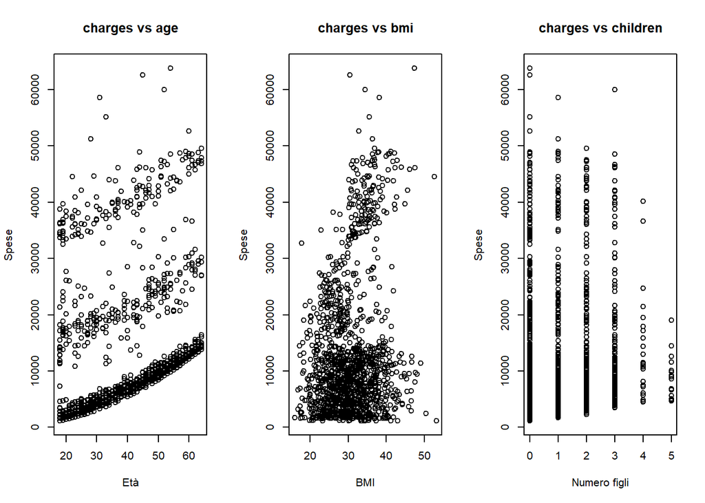

```r
# Grafici a dispersione tra charges e le variabili numeriche
par(mfrow = c(1, 3))
plot(insurance$age, insurance$charges, xlab = "Età", ylab = "Spese", main = "charges vs age")
plot(insurance$bmi, insurance$charges, xlab = "BMI", ylab = "Spese", main = "charges vs bmi")
plot(insurance$children, insurance$charges, xlab = "Numero figli", ylab = "Spese", main = "charges vs children")
```

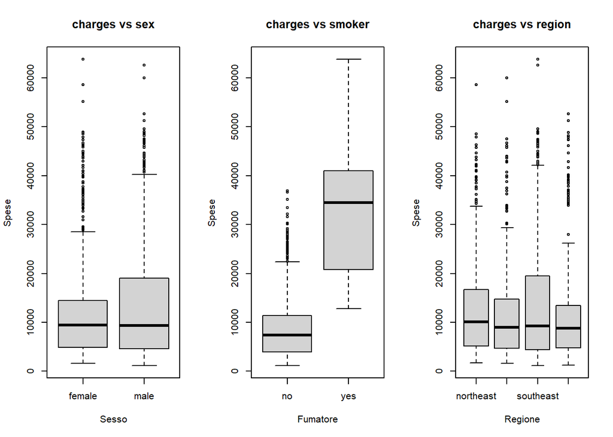

```r
# Boxplot per le variabili categoriali
par(mfrow = c(1, 3))
boxplot(charges ~ sex, data = insurance, xlab = "Sesso", ylab = "Spese", main = "charges vs sex")
boxplot(charges ~ smoker, data = insurance, xlab = "Fumatore", ylab = "Spese", main = "charges vs smoker")
boxplot(charges ~ region, data = insurance, xlab = "Regione", ylab = "Spese", main = "charges vs region")
```

## 💥 Risposta

Dall’analisi esplorativa emergono le seguenti relazioni:

- **age**: Si osserva una relazione positiva moderata (correlazione ≈ 0.30). All’aumentare dell’età, le spese mediche tendono ad aumentare, anche se con una certa variabilità.
- **bmi**: La correlazione è molto debole (≈ 0.20). Non sembra esserci una relazione lineare chiara tra indice di massa corporea e spese mediche.
- **children**: La correlazione è molto bassa (≈ 0.07). Il numero di figli a carico non sembra influenzare in modo significativo le spese mediche.
- **sex**: Le spese mediche sono simili tra maschi e femmine, con una leggera variabilità.
- **smoker**: Questa variabile mostra una differenza sostanziale. I fumatori hanno spese mediche molto più elevate rispetto ai non fumatori.
- **region**: Le quattro regioni presentano distribuzioni simili delle spese mediche, senza differenze evidenti.

La variabile che sembra avere l’impatto più rilevante sulle spese mediche è `smoker`, seguita da `age`.

### 🔹 Punto b)

Costruire un primo modello di regressione lineare per le spese mediche selezionando come esplicativa la variabile `age`. Interpretare i coefficienti del modello, valutare la bontà di adattamento ed analizzare i residui.

```r
# Modello lineare semplice con age
modello_age <- lm(charges ~ age, data = insurance)
summary(modello_age)
```

```
##
## Call:
## lm(formula = charges ~ age, data = insurance)
##
## Residuals:
##    Min     1Q Median     3Q    Max
##  -8059  -6671  -5939   5440  47829
##
## Coefficients:
##             Estimate Std. Error t value Pr(>|t|)
## (Intercept)   3165.9      937.1   3.378 0.000751 ***
## age            257.7       22.5  11.453  < 2e-16 ***
## ---
## Signif. codes:  0 '***' 0.001 '**' 0.01 '*' 0.05 '.' 0.1 ' ' 1
##
## Residual standard error: 11560 on 1336 degrees of freedom
## Multiple R-squared:  0.08941,    Adjusted R-squared:  0.08872
## F-statistic: 131.2 on 1 and 1336 DF,  p-value: < 2.2e-16
```

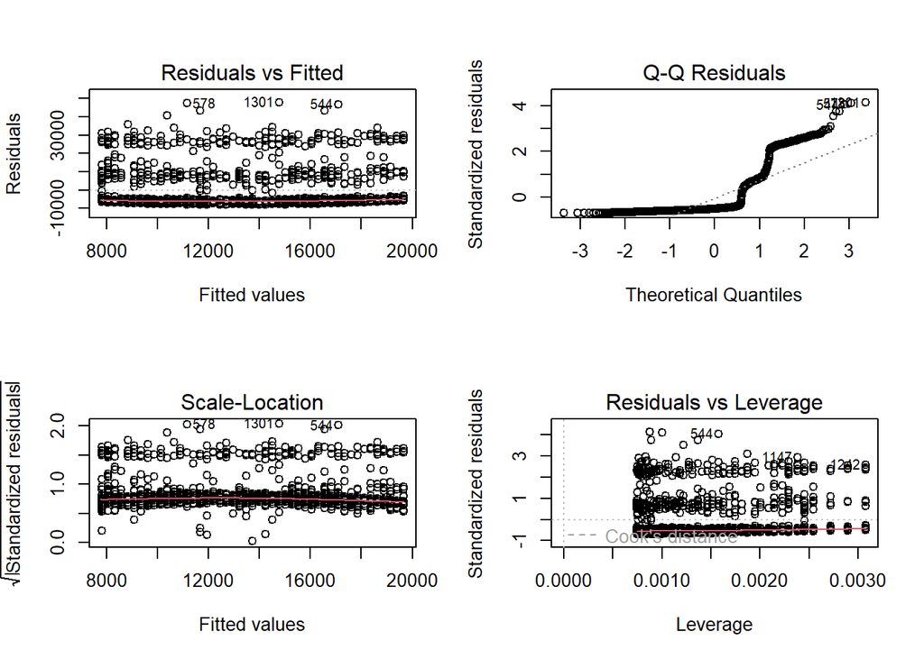

```r
# Analisi dei residui
par(mfrow = c(2, 2))
plot(modello_age)
```

## 💥 Risposta

Il modello `charges ~ age` fornisce i seguenti risultati:

**Analisi dei residui**: Dai grafici si osserva che: - I residui non sono distribuiti casualmente intorno allo zero (pattern a ventaglio) - La varianza dei residui non è costante (eteroschedasticità) - I residui non seguono una distribuzione normale (deviazioni sulla coda destra)

Il modello con la sola `age` non è adeguato per descrivere le spese mediche.

### 🔹 Punto c)

Disegnare lo scatterplot per le variabili `age` e `charges` ed aggiungere al grafico la retta di regressione stimata al punto precedente. Evidenziare sul grafico, con bande colorate, uno scostamento di un anno sull’età ed il rispettivo incremento atteso sulle spese mediche stimato dal modello.

```r
# Scatterplot con retta di regressione
plot(insurance$age, insurance$charges,
     xlab = "Età (anni)", ylab = "Spese mediche ($)",
     main = "Spese mediche vs Età con retta di regressione",
     col = "darkgray", pch = 16)
abline(modello_age, col = "red", lwd = 2)

# Estraggo il coefficiente di age
coeff_age <- coef(modello_age)["age"]
cat("Incremento atteso per un anno in più di età:", round(coeff_age, 2), "dollari\n")
```

```
## Incremento atteso per un anno in più di età: 257.72 dollari
```

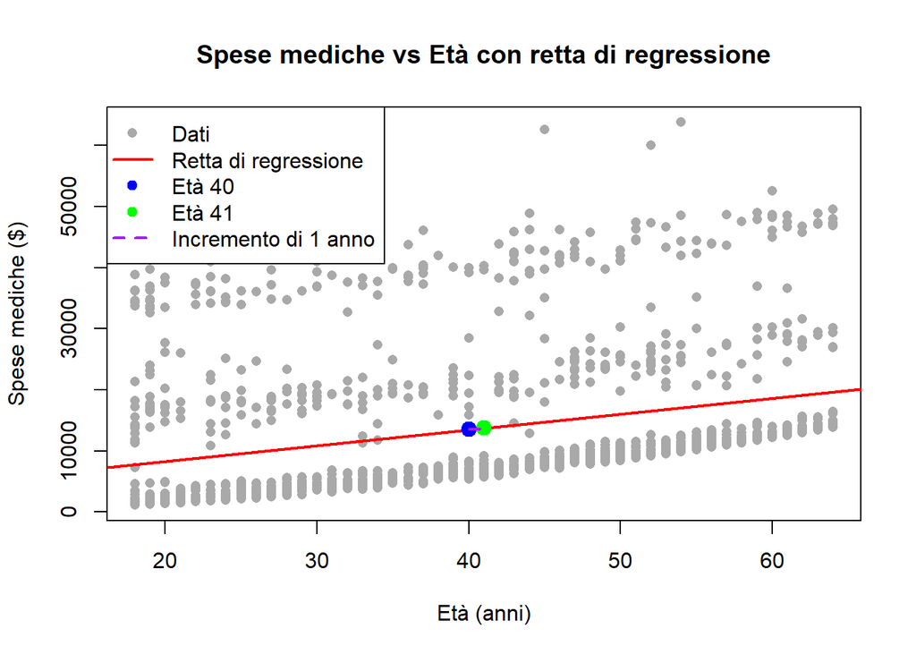

```r
# Aggiungo una banda per visualizzare l'incremento
# Prendo un'età di riferimento (es. 40 anni)
eta_riferimento <- 40
spese_riferimento <- predict(modello_age, newdata = data.frame(age = eta_riferimento))
spese_incremento <- predict(modello_age, newdata = data.frame(age = eta_riferimento + 1))

# Evidenzio i due punti e l'incremento
points(eta_riferimento, spese_riferimento, col = "blue", pch = 19, cex = 1.5)
points(eta_riferimento + 1, spese_incremento, col = "green", pch = 19, cex = 1.5)
segments(eta_riferimento, spese_riferimento, eta_riferimento + 1, spese_incremento,
         col = "purple", lwd = 2, lty = 2)

# Legenda
legend("topleft", legend = c("Dati", "Retta di regressione",
                              paste("Età", eta_riferimento),
                              paste("Età", eta_riferimento + 1),
                              "Incremento di 1 anno"),
       col = c("darkgray", "red", "blue", "green", "purple"),
       pch = c(16, NA, 19, 19, NA), lwd = c(NA, 2, NA, NA, 2),
       lty = c(NA, 1, NA, NA, 2))
```

## 💥 Risposta

### 🔹 Punto d)

Aggiungere al modello la variabile `smoker` e valutare l’introduzione dell’interazione tra `age` e `smoker`. Valutare il modello e ripetere i punti b e c.

```r
library(ggplot2)

# Modello con age e smoker (senza interazione)
modello_smk <- lm(charges ~ age + smoker, data = insurance)

# Modello con interazione tra age e smoker
modello_int <- lm(charges ~ age * smoker, data = insurance)

# Confronto tra i modelli
anova(modello_smk, modello_int)
```

```
## Analysis of Variance Table
##
## Model 1: charges ~ age + smoker
## Model 2: charges ~ age * smoker
##   Res.Df        RSS Df Sum of Sq      F Pr(>F)
## 1   1335 5.4626e+10
## 2   1334 5.4565e+10  1  61050289 1.4925  0.222
```

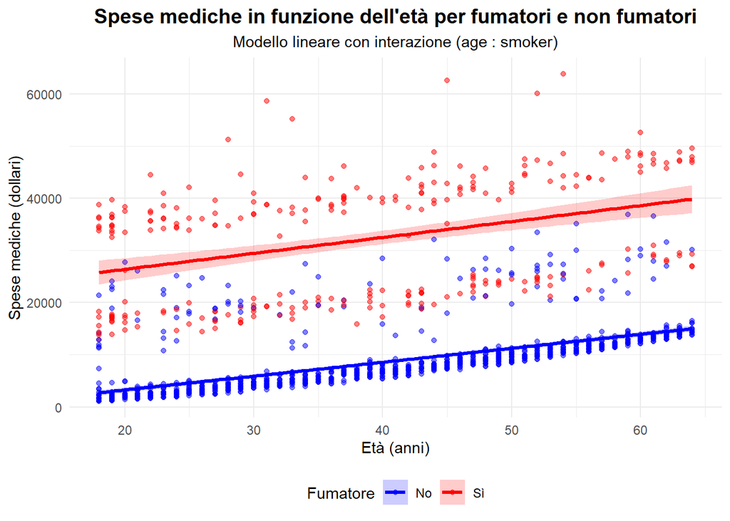

```r
# Grafico con ggplot2
ggplot(insurance, aes(x = age, y = charges, color = smoker, fill = smoker)) +
  geom_point(alpha = 0.5, size = 1.5) +
  geom_smooth(method = "lm", se = TRUE, size = 1.2, alpha = 0.2) +
  labs(
    title = "Spese mediche in funzione dell'età per fumatori e non fumatori",
    subtitle = "Modello lineare con interazione (age : smoker)",
    x = "Età (anni)",
    y = "Spese mediche (dollari)",
    color = "Fumatore",
    fill = "Fumatore"
  ) +
  theme_minimal() +
  theme(
    plot.title = element_text(hjust = 0.5, face = "bold", size = 14),
    plot.subtitle = element_text(hjust = 0.5, size = 11),
    legend.position = "bottom"
  ) +
  scale_color_manual(values = c("blue", "red"), labels = c("No", "Sì")) +
  scale_fill_manual(values = c("blue", "red"), labels = c("No", "Sì"))
```

## 💥 Risposta

L’aggiunta della variabile `smoker` migliora notevolmente il modello:

### 🔹 Punto e)

Qual è la spesa medica attesa per un individuo di 40 anni fumatore? E per un individuo della stessa età non fumatore?

```r
# Previsioni con il modello migliore (senza interazione)
previsione_fumatore <- predict(modello_smk,
                               newdata = data.frame(age = 40, smoker = "yes"))
previsione_non_fumatore <- predict(modello_smk,
                                   newdata = data.frame(age = 40, smoker = "no"))

cat("Spesa attesa per un 40enne FUMATORE:", round(previsione_fumatore, 2), "dollari\n")
```

```
## Spesa attesa per un 40enne FUMATORE: 32458.53 dollari
```

```r
cat("Spesa attesa per un 40enne NON FUMATORE:", round(previsione_non_fumatore, 2), "dollari\n")
```

```
## Spesa attesa per un 40enne NON FUMATORE: 8603.22 dollari
```

```r
cat("Differenza:", round(previsione_fumatore - previsione_non_fumatore, 2), "dollari\n")
```

```
## Differenza: 23855.3 dollari
```

## 💥 Risposta

# Esercizio 4

Nel file `wages.csv`, sono registrate, per un campione di lavoratori, le seguenti variabili:

- `exper`: anni di esperienza lavorativa (in anni),
- `sex`: genere (1 se donna),
- `school`: scolarità (in anni),
- `wage`: remunerazione oraria.

## ✏️ Svolgimento

### 🔹 Punto a)

Volendo stimare un modello di regressione lineare che consideri la variabile remunerazione oraria come variabile risposta, visualizzare e commentare le relazioni a coppie tra la variabile `wage` e le altre presenti nel data set con opportuni strumenti grafici e numerici.

```r
# Carico il dataset
wages <- read.csv("wages.csv")

# Visualizzo le prime righe
head(wages)
```

```
##   exper sex school wage
## 1     2   1     11 3.10
## 2    22   1     12 3.24
## 3     2   0     11 3.00
## 4    44   0      8 6.00
## 5     7   0     12 5.30
## 6     9   0     16 8.75
```

```r
# Struttura del dataset
str(wages)
```

```
## 'data.frame':    526 obs. of  4 variables:
##  $ exper : int  2 22 2 44 7 9 15 5 26 22 ...
##  $ sex   : int  1 1 0 0 0 0 0 1 1 0 ...
##  $ school: int  11 12 11 8 12 16 18 12 12 17 ...
##  $ wage  : num  3.1 3.24 3 6 5.3 ...
```

```r
# Statistiche descrittive
summary(wages)
```

```
##      exper            sex             school           wage
##  Min.   : 1.00   Min.   :0.0000   Min.   : 0.00   Min.   : 0.530
##  1st Qu.: 5.00   1st Qu.:0.0000   1st Qu.:12.00   1st Qu.: 3.330
##  Median :13.50   Median :0.0000   Median :12.00   Median : 4.650
##  Mean   :17.02   Mean   :0.4791   Mean   :12.56   Mean   : 5.896
##  3rd Qu.:26.00   3rd Qu.:1.0000   3rd Qu.:14.00   3rd Qu.: 6.880
##  Max.   :51.00   Max.   :1.0000   Max.   :18.00   Max.   :24.980
```

```r
# Correlazioni tra wage e le variabili numeriche
cor(wages[, c("exper", "school", "wage")])
```

```
##             exper     school      wage
## exper   1.0000000 -0.2995418 0.1129034
## school -0.2995418  1.0000000 0.4059033
## wage    0.1129034  0.4059033 1.0000000
```

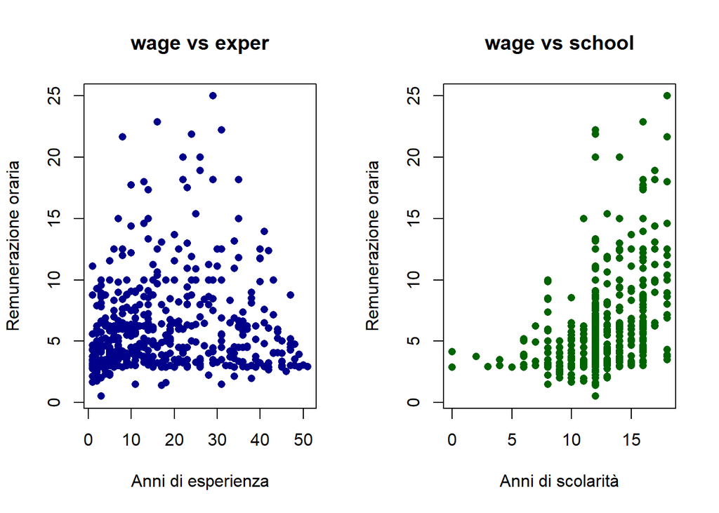

```r
# Grafici a dispersione
par(mfrow = c(1, 2))
plot(wages$exper, wages$wage,
     xlab = "Anni di esperienza", ylab = "Remunerazione oraria",
     main = "wage vs exper", col = "darkblue", pch = 16)
plot(wages$school, wages$wage,
     xlab = "Anni di scolarità", ylab = "Remunerazione oraria",
     main = "wage vs school", col = "darkgreen", pch = 16)
```

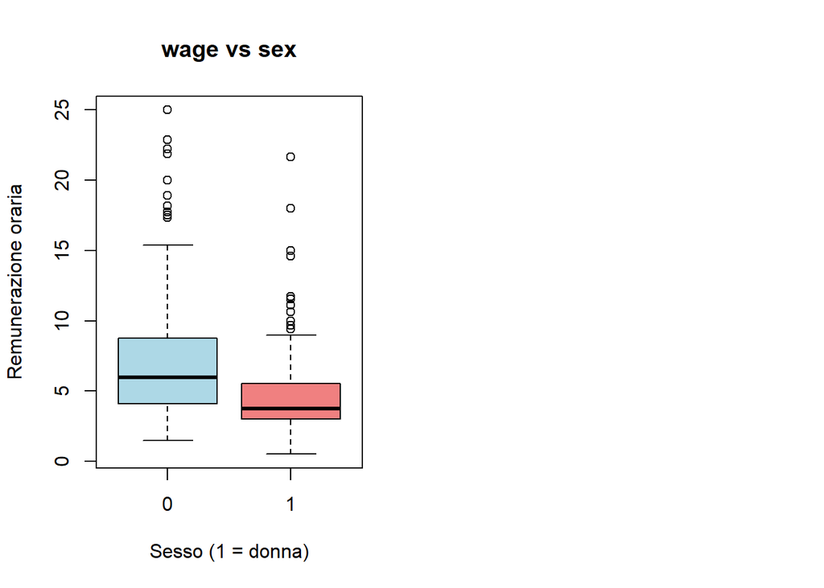

```r
# Boxplot per il sesso
boxplot(wage ~ sex, data = wages,
        xlab = "Sesso (1 = donna)", ylab = "Remunerazione oraria",
        main = "wage vs sex", col = c("lightblue", "lightcoral"))
```

## 💥 Risposta

Dall’analisi esplorativa emergono le seguenti relazioni:

### 🔹 Punto b)

Stima un modello di regressione lineare semplice utilizzando solo gli anni di esperienza (`exper` come variabile esplicativa).

```r
# Modello lineare semplice con exper
modello_exper <- lm(wage ~ exper, data = wages)
summary(modello_exper)
```

```
##
## Call:
## lm(formula = wage ~ exper, data = wages)
##
## Residuals:
##    Min     1Q Median     3Q    Max
## -4.936 -2.458 -1.112  1.077 18.716
##
## Coefficients:
##             Estimate Std. Error t value Pr(>|t|)
## (Intercept)  5.37331    0.25699  20.908  < 2e-16 ***
## exper        0.03072    0.01181   2.601  0.00955 **
## ---
## Signif. codes:  0 '***' 0.001 '**' 0.01 '*' 0.05 '.' 0.1 ' ' 1
##
## Residual standard error: 3.673 on 524 degrees of freedom
## Multiple R-squared:  0.01275,    Adjusted R-squared:  0.01086
## F-statistic: 6.766 on 1 and 524 DF,  p-value: 0.009555
```

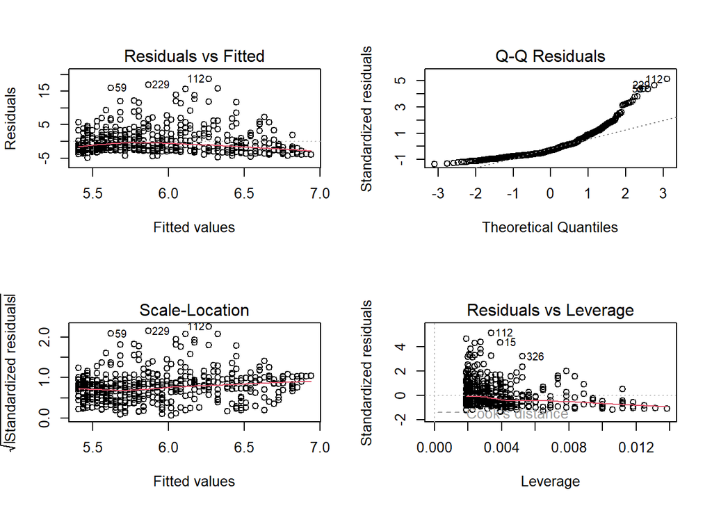

```r
# Analisi dei residui
par(mfrow = c(2, 2))
plot(modello_exper)
```

## 💥 Risposta

Il modello `wage ~ exper` fornisce i seguenti risultati:

**Analisi dei residui**: Dai grafici si osserva che i residui non sono perfettamente distribuiti casualmente, con qualche outlier e una leggera non normalità.

Il modello con la sola `exper` spiega una piccola parte della variabilità della remunerazione.

### 🔹 Punto c)

Ottieni i residui della regressione semplice e fai il grafico dei residui contro le restanti variabili (sesso incluso). Che indicazioni potresti ricavare da questa analisi?

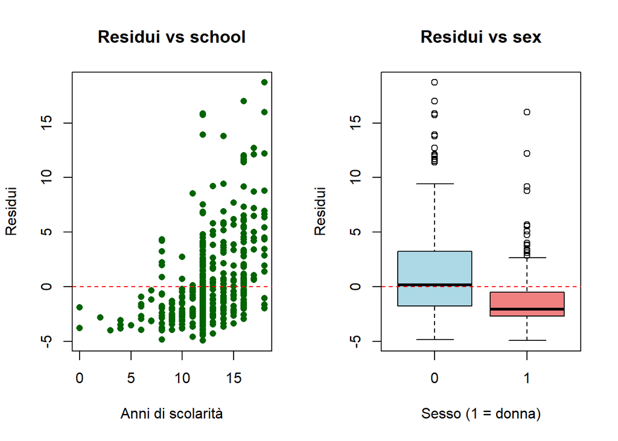

```r
# Estraggo i residui del modello
wages$residui <- residuals(modello_exper)

# Grafici dei residui vs variabili non incluse
par(mfrow = c(1, 2))
plot(wages$school, wages$residui,
     xlab = "Anni di scolarità", ylab = "Residui",
     main = "Residui vs school", col = "darkgreen", pch = 16)
abline(h = 0, col = "red", lty = 2)

boxplot(residui ~ sex, data = wages,
        xlab = "Sesso (1 = donna)", ylab = "Residui",
        main = "Residui vs sex", col = c("lightblue", "lightcoral"))
abline(h = 0, col = "red", lty = 2)
```

## 💥 Risposta

Dall’analisi dei residui emergono indicazioni importanti:

- **Residui vs school**: Si osserva un pattern sistematico: per bassi livelli di scolarità i residui tendono ad essere negativi, mentre per alti livelli di scolarità i residui tendono ad essere positivi. Questo suggerisce che la variabile `school` (scolarità) è correlata con la remunerazione e dovrebbe essere inclusa nel modello.
- **Residui vs sex**: Si osserva che i residui per le donne (sex = 1) tendono ad essere leggermente più bassi rispetto agli uomini. Questo suggerisce che anche il genere potrebbe avere un effetto sulla remunerazione, e dovrebbe essere considerato nel modello.

Queste evidenze indicano che il modello semplice con la sola `exper` è **inadeguato** e che per migliorare la capacità predittiva è necessario aggiungere altre variabili esplicative, in particolare `school` e `sex`.

### 🔹 Punto d)

Stima un opportuno modello di regressione multipla, giustificando le scelte effettuate in termini di selezione del modello.

```r
# Modello con tutte le variabili
modello_completo <- lm(wage ~ exper + sex + school, data = wages)
summary(modello_completo)
```

```
##
## Call:
## lm(formula = wage ~ exper + sex + school, data = wages)
##
## Residuals:
##     Min      1Q  Median      3Q     Max
## -6.3856 -1.9652 -0.4931  1.1199 14.8217
##
## Coefficients:
##             Estimate Std. Error t value Pr(>|t|)
## (Intercept) -1.73448    0.75362  -2.302   0.0218 *
## exper        0.06424    0.01040   6.177 1.32e-09 ***
## sex         -2.15552    0.27031  -7.974 9.74e-15 ***
## school       0.60258    0.05112  11.788  < 2e-16 ***
## ---
## Signif. codes:  0 '***' 0.001 '**' 0.01 '*' 0.05 '.' 0.1 ' ' 1
##
## Residual standard error: 3.078 on 522 degrees of freedom
## Multiple R-squared:  0.3093, Adjusted R-squared:  0.3053
## F-statistic: 77.92 on 3 and 522 DF,  p-value: < 2.2e-16
```

```r
# Selezione automatica del modello (stepwise)
modello_step <- step(modello_completo, direction = "both")
```

```
## Start:  AIC=1186.75
## wage ~ exper + sex + school
##
##          Df Sum of Sq    RSS    AIC
## <none>                4945.7 1186.8
## - exper   1    361.49 5307.2 1221.8
## - sex     1    602.49 5548.2 1245.2
## - school  1   1316.58 6262.3 1308.9
```

```r
summary(modello_step)
```

```
##
## Call:
## lm(formula = wage ~ exper + sex + school, data = wages)
##
## Residuals:
##     Min      1Q  Median      3Q     Max
## -6.3856 -1.9652 -0.4931  1.1199 14.8217
##
## Coefficients:
##             Estimate Std. Error t value Pr(>|t|)
## (Intercept) -1.73448    0.75362  -2.302   0.0218 *
## exper        0.06424    0.01040   6.177 1.32e-09 ***
## sex         -2.15552    0.27031  -7.974 9.74e-15 ***
## school       0.60258    0.05112  11.788  < 2e-16 ***
## ---
## Signif. codes:  0 '***' 0.001 '**' 0.01 '*' 0.05 '.' 0.1 ' ' 1
##
## Residual standard error: 3.078 on 522 degrees of freedom
## Multiple R-squared:  0.3093, Adjusted R-squared:  0.3053
## F-statistic: 77.92 on 3 and 522 DF,  p-value: < 2.2e-16
```

```r
# Confronto tra i modelli
anova(modello_exper, modello_completo)
```

```
## Analysis of Variance Table
##
## Model 1: wage ~ exper
## Model 2: wage ~ exper + sex + school
##   Res.Df    RSS Df Sum of Sq      F    Pr(>F)
## 1    524 7069.1
## 2    522 4945.7  2    2123.5 112.06 < 2.2e-16 ***
## ---
## Signif. codes:  0 '***' 0.001 '**' 0.01 '*' 0.05 '.' 0.1 ' ' 1
```

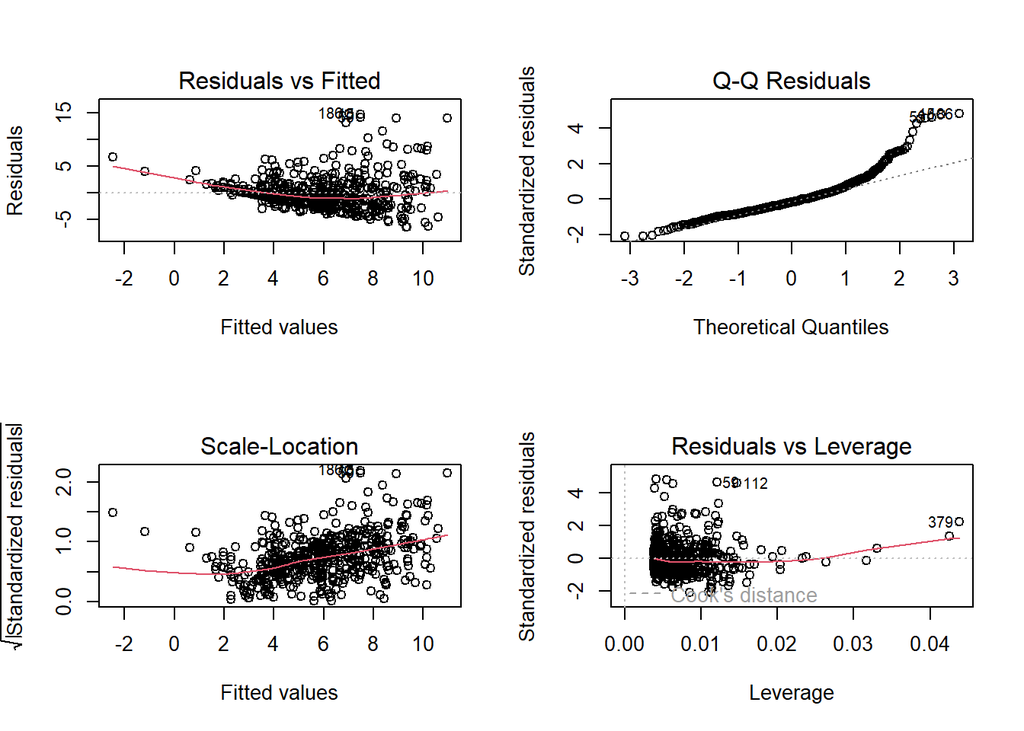

```r
# Analisi dei residui del modello scelto
par(mfrow = c(2, 2))
plot(modello_step)
```

## 💥 Risposta

Ho stimato un modello di regressione multipla con tutte e tre le variabili esplicative (`exper`, `sex`, `school`). I risultati mostrano:

La selezione automatica (stepwise) ha confermato che tutte e tre le variabili sono utili, mantenendole tutte nel modello finale.

Il test ANOVA tra il modello semplice (`wage ~ exper`) e il modello completo è altamente significativo (p-value < 2.2e-16), confermando che l’aggiunta di `sex` e `school` migliora significativamente il modello.

### 🔹 Punto e)

Quanta remunerazione aggiuntiva ci si può attendere, a parità del resto, per ogni anno di esperienza in più?

```r
# Estraggo il coefficiente di exper dal modello scelto
coeff_exper <- coef(modello_step)["exper"]
cat("Remunerazione aggiuntiva attesa per un anno di esperienza in più:",
    round(coeff_exper, 3), "dollari\n")
```

```
## Remunerazione aggiuntiva attesa per un anno di esperienza in più: 0.064 dollari
```

## 💥 Risposta

### 🔹 Punto f)

Per un individuo di sesso maschile, con 11 anni di scolarità e 7 di esperienza lavorativa, quale remunerazione ci si attende?

```r
# Previsione per un individuo maschio (sex = 0) con school = 11 e exper = 7
previsione <- predict(modello_step,
                      newdata = data.frame(exper = 7, sex = 0, school = 11))
cat("Remunerazione attesa:", round(previsione, 2), "dollari/ora\n")
```

```
## Remunerazione attesa: 5.34 dollari/ora
```

## 💥 Risposta

### 🔹 Punto g)

Potrebbe aver senso considerare una trasformazione della variabile risposta? E delle esplicative?

```r
# Verifica della normalità dei residui del modello attuale
shapiro.test(residuals(modello_step))
```

```
##
##  Shapiro-Wilk normality test
##
## data:  residuals(modello_step)
## W = 0.88026, p-value < 2.2e-16
```

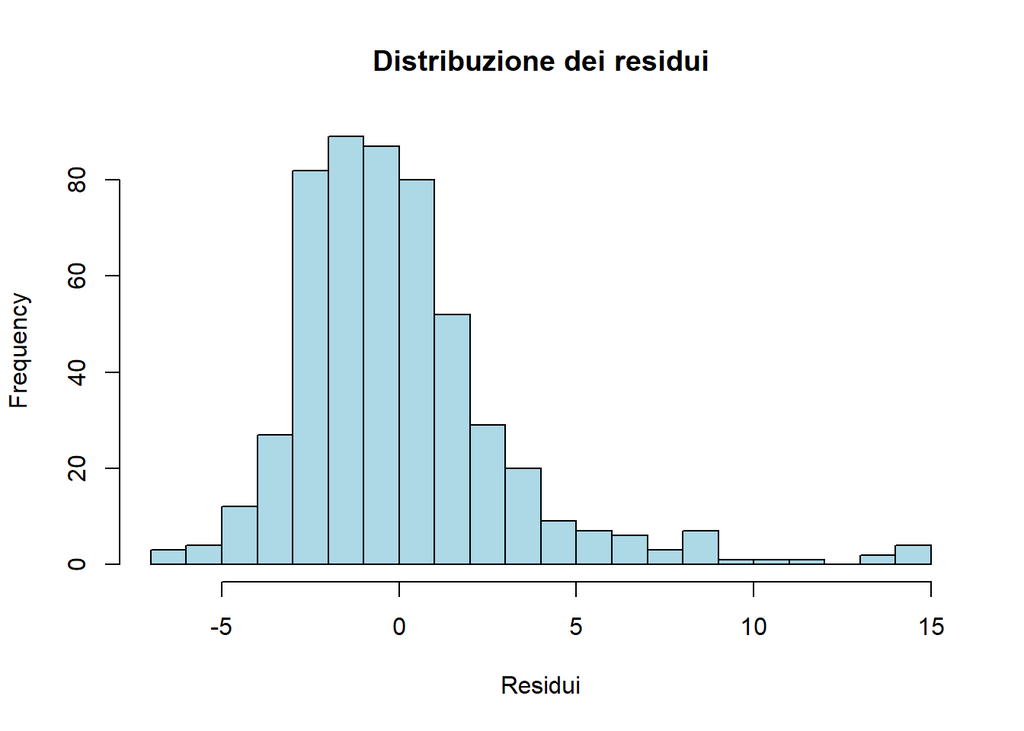

```r
# Istogramma dei residui
hist(residuals(modello_step), breaks = 30,
     main = "Distribuzione dei residui",
     xlab = "Residui", col = "lightblue")
```

```r
# Proviamo una trasformazione logaritmica della risposta
wages$log_wage <- log(wages$wage)
modello_log <- lm(log_wage ~ exper + sex + school, data = wages)
summary(modello_log)
```

```
##
## Call:
## lm(formula = log_wage ~ exper + sex + school, data = wages)
##
## Residuals:
##      Min       1Q   Median       3Q      Max
## -1.89584 -0.26362 -0.03871  0.26765  1.28241
##
## Coefficients:
##              Estimate Std. Error t value Pr(>|t|)
## (Intercept)  0.480836   0.105016   4.579 5.86e-06 ***
## exper        0.009414   0.001449   6.496 1.93e-10 ***
## sex         -0.343597   0.037667  -9.122  < 2e-16 ***
## school       0.091290   0.007123  12.816  < 2e-16 ***
## ---
## Signif. codes:  0 '***' 0.001 '**' 0.01 '*' 0.05 '.' 0.1 ' ' 1
##
## Residual standard error: 0.4289 on 522 degrees of freedom
## Multiple R-squared:  0.3526, Adjusted R-squared:  0.3488
## F-statistic: 94.75 on 3 and 522 DF,  p-value: < 2.2e-16
```

```r
# Confronto R² dei due modelli
cat("R² modello originale:", summary(modello_step)$r.squared, "\n")
```

```
## R² modello originale: 0.3093036
```

```r
cat("R² modello log:", summary(modello_log)$r.squared, "\n")
```

```
## R² modello log: 0.3525517
```

```r
# Verifica della normalità dei residui del modello log
shapiro.test(residuals(modello_log))
```

```
##
##  Shapiro-Wilk normality test
##
## data:  residuals(modello_log)
## W = 0.991, p-value = 0.002734
```

## 💥 Risposta

**Sulla trasformazione delle variabili esplicative:**

- Potrebbe avere senso considerare un termine quadratico per `exper`, poiché la relazione tra esperienza e remunerazione potrebbe non essere lineare (effetti decrescenti nel tempo).
- Anche per `school` si potrebbe ipotizzare una relazione non lineare, ma dai grafici la relazione sembra approssimativamente lineare.

**Conclusione:** La trasformazione logaritmica della risposta è consigliabile per avvicinarsi all’assunzione di normalità dei residui, anche se non la risolve completamente. Per migliorare ulteriormente il modello, si potrebbero aggiungere termini polinomiali per `exper`.

# Esercizio 5

Il dataset `mtcars`, contiene caratteristiche di 32 automobili degli anni ’70. Le variabili principali sono:  
- `mpg` (miglia per gallone)  
- `hp` (cavalli)  
- `wt` (peso in migliaia di libbre)  
- `disp` (cilindrata).

## ✏️ Svolgimento

### 🔹 Punto a)

Si calcoli la correlazione marginale tra `mpg` e `hp`. Il segno è quello atteso?

```r
# Carico il dataset mtcars
data(mtcars)

# Calcolo la correlazione tra mpg e hp
cor_mpg_hp <- cor(mtcars$mpg, mtcars$hp)
cat("Correlazione tra mpg e hp:", round(cor_mpg_hp, 4), "\n")
```

```
## Correlazione tra mpg e hp: -0.7762
```

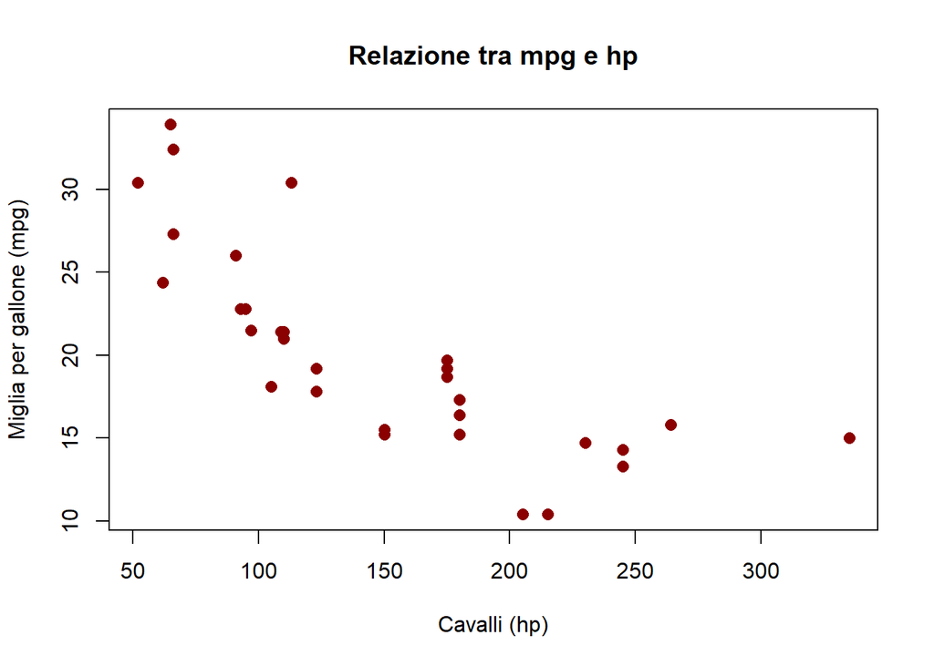

```r
# Grafico a dispersione
plot(mtcars$hp, mtcars$mpg,
     xlab = "Cavalli (hp)", ylab = "Miglia per gallone (mpg)",
     main = "Relazione tra mpg e hp",
     col = "darkred", pch = 16, cex = 1.2)
```

## 💥 Risposta

La correlazione marginale tra `mpg` (miglia per gallone) e `hp` (cavalli) è **-0.7762**.

Il segno è **negativo**, come atteso: all’aumentare della potenza del motore (cavalli), il consumo di carburante aumenta, quindi il numero di miglia per gallone diminuisce. La correlazione è piuttosto forte in valore assoluto, indicando una relazione lineare negativa sostanziale tra le due variabili.

### 🔹 Punto b)

Si osserva che `hp` e `wt` sono entrambe correlate con `mpg`. Si calcoli la correlazione parziale tra `mpg` e `hp` al netto di `wt`, usando il metodo dei residui. La correlazione diminuisce rispetto a quella marginale?

```r
# Metodo dei residui per la correlazione parziale

# 1. Regredisco mpg su wt e ne estraggo i residui
modello_mpg_wt <- lm(mpg ~ wt, data = mtcars)
residui_mpg <- residuals(modello_mpg_wt)

# 2. Regredisco hp su wt e ne estraggo i residui
modello_hp_wt <- lm(hp ~ wt, data = mtcars)
residui_hp <- residuals(modello_hp_wt)

# 3. Correlazione tra i due residui
cor_parziale_mpg_hp_wt <- cor(residui_mpg, residui_hp)
cat("Correlazione parziale tra mpg e hp al netto di wt:", round(cor_parziale_mpg_hp_wt, 4), "\n")
```

```
## Correlazione parziale tra mpg e hp al netto di wt: -0.547
```

```r
cat("Correlazione marginale (mpg, hp):", round(cor_mpg_hp, 4), "\n")
```

```
## Correlazione marginale (mpg, hp): -0.7762
```

```r
cat("Differenza:", round(cor_mpg_hp - cor_parziale_mpg_hp_wt, 4), "\n")
```

```
## Differenza: -0.2292
```

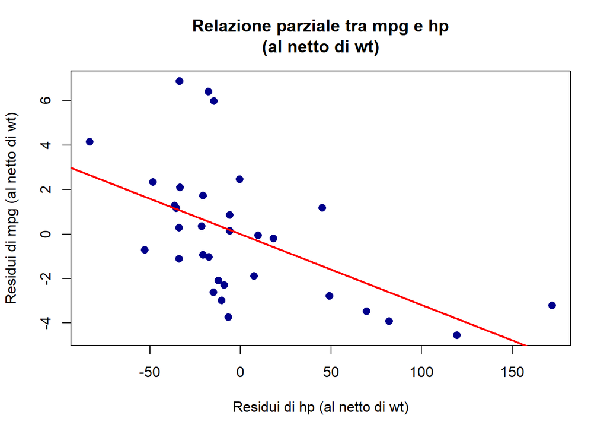

```r
# Grafico dei residui per visualizzare la relazione parziale
plot(residui_hp, residui_mpg,
     xlab = "Residui di hp (al netto di wt)",
     ylab = "Residui di mpg (al netto di wt)",
     main = "Relazione parziale tra mpg e hp\n(al netto di wt)",
     col = "darkblue", pch = 16, cex = 1.2)
abline(lm(residui_mpg ~ residui_hp), col = "red", lwd = 2)
```

## 💥 Risposta

Il grafico dei residui mostra la relazione tra le due variabili dopo aver rimosso l’effetto lineare del peso.

### 🔹 Punto c)

Si calcoli la stessa correlazione parziale usando la formula diretta:

$$r_{xy.z} = \frac{r_{xy} -
r_{xz}\,r_{yz}}{\sqrt{1-r_{xz}^2}\,\sqrt{1-r_{yz}^2}}$$

e si verifichi che il risultato coincida con quello ottenuto al punto b.

```r
# Calcolo delle correlazioni marginali
r_xy <- cor(mtcars$mpg, mtcars$hp)      # mpg vs hp
r_xz <- cor(mtcars$mpg, mtcars$wt)      # mpg vs wt
r_yz <- cor(mtcars$hp, mtcars$wt)       # hp vs wt

# Formula della correlazione parziale
r_xy_z <- (r_xy - r_xz * r_yz) / (sqrt(1 - r_xz^2) * sqrt(1 - r_yz^2))

cat("Correlazione parziale con formula diretta:", round(r_xy_z, 4), "\n")
```

```
## Correlazione parziale con formula diretta: -0.547
```

```r
cat("Correlazione parziale con metodo dei residui:", round(cor_parziale_mpg_hp_wt, 4), "\n")
```

```
## Correlazione parziale con metodo dei residui: -0.547
```

```r
cat("Le due quantità coincidono?", abs(r_xy_z - cor_parziale_mpg_hp_wt) < 1e-8, "\n")
```

```
## Le due quantità coincidono? TRUE
```

## 💥 Risposta

La formula diretta permette di calcolare la correlazione parziale conoscendo solo le correlazioni marginali, senza dover eseguire le due regressioni lineari. In questo caso:

- $r_{xy}$ (mpg vs hp) = -0.7762
- $r_{xz}$ (mpg vs wt) = -0.8677
- $r_{yz}$ (hp vs wt) = 0.6587

Sostituendo nella formula si ottiene lo stesso risultato del metodo dei residui, verificando così la correttezza di entrambi gli approcci.

# Esercizio 6

I dati presenti nel file `sanita.txt` si riferiscono a un rilevamento ISTAT sui servizi sanitari delle regioni italiane. Le variabili riportano:

- `medici`: numero di medici per 10000 abitanti
- `postiletto`: numero di posti ospedalieri per 10000 abitanti
- `pediatri`: numero di pediatri per 10000 abitanti di età inferiore ai 14 anni
- `interv_PS`: numero annuo di interventi di pronto soccorso per 1000 abitanti
- `soddisfaz`: percentuale di persone che si sono dichiarate soddisfatte dell’assistenza medica ospedaliera

## ✏️ Svolgimento

### 🔹 Punto a)

Valutare la possibilità di standardizzare le variabili del dataset e motivare la scelta.

```r
# Carico il dataset
sanita <- read.table("sanita.txt", header = TRUE, row.names = 1)

# Visualizzo le prime righe
head(sanita)
```

```
##                      medici postiletto pediatri interv_PS soddisfaz
## Piemonte               8.47        5.0     8.38     413.9      48.5
## ValledAosta            8.60        4.2     8.68     298.2      35.5
## Lombardia              8.18        5.5     7.80     386.6      48.5
## Trentino-AltoAdige     6.13        6.2     6.86     423.6      56.8
## Veneto                 7.99        5.3     8.46     454.3      61.5
## Friuli-VeneziaGiulia   8.84        5.7     7.40     393.4      51.8
```

```r
# Statistiche descrittive
summary(sanita)
```

```
##      medici        postiletto       pediatri        interv_PS
##  Min.   :6.130   Min.   :4.200   Min.   : 5.880   Min.   :264.0
##  1st Qu.:7.985   1st Qu.:4.850   1st Qu.: 7.692   1st Qu.:356.4
##  Median :8.350   Median :5.300   Median : 8.420   Median :396.5
##  Mean   :8.312   Mean   :5.240   Mean   : 8.524   Mean   :390.3
##  3rd Qu.:8.633   3rd Qu.:5.625   3rd Qu.: 9.213   3rd Qu.:416.3
##  Max.   :9.970   Max.   :6.500   Max.   :11.330   Max.   :515.5
##    soddisfaz
##  Min.   :17.70
##  1st Qu.:33.88
##  Median :42.55
##  Mean   :40.66
##  3rd Qu.:48.90
##  Max.   :61.50
```

```r
# Calcolo le deviazioni standard per valutare l'ordine di grandezza
sd_medici <- sd(sanita$medici)
sd_postiletto <- sd(sanita$postiletto)
sd_pediatri <- sd(sanita$pediatri)
sd_interv_PS <- sd(sanita$interv_PS)
sd_soddisfaz <- sd(sanita$soddisfaz)

cat("Deviazioni standard:\n")
```

```
## Deviazioni standard:
```

```r
cat("medici:", round(sd_medici, 2), "\n")
```

```
## medici: 0.74
```

```r
cat("postiletto:", round(sd_postiletto, 2), "\n")
```

```
## postiletto: 0.69
```

```r
cat("pediatri:", round(sd_pediatri, 2), "\n")
```

```
## pediatri: 1.4
```

```r
cat("interv_PS:", round(sd_interv_PS, 2), "\n")
```

```
## interv_PS: 56.79
```

```r
cat("soddisfaz:", round(sd_soddisfaz, 2), "\n")
```

```
## soddisfaz: 11.38
```

## 💥 Risposta

Le variabili del dataset sono espresse in unità di misura diverse: - `medici`, `postiletto`, `pediatri`: valori tra 4 e 11 - `interv_PS`: valori tra 250 e 520 - `soddisfaz`: valori tra 17 e 62

**La standardizzazione è necessaria** perché: 1. Le variabili sono misurate su scale diverse 2. Per il calcolo delle distanze (necessario per il clustering), variabili con scale più ampie dominerebbero quelle con scale più piccole 3. La standardizzazione rende tutte le variabili con media 0 e varianza 1, dando lo stesso peso a ciascuna variabile

### 🔹 Punto b)

Calcolare la matrice delle distanze, scegliendo un’opportuna metrica. Qual è la distanza tra Piemonte e Lombardia? E tra Lombardia e Trentino-AltoAdige?

```r
# Standardizzazione dei dati
sanita_scaled <- scale(sanita)

# Matrice delle distanze (distanza euclidea)
distanze <- dist(sanita_scaled, method = "euclidean")

# Converto in matrice per estrarre le distanze specifiche
matrice_distanze <- as.matrix(distanze)

# Distanza tra Piemonte e Lombardia
dist_Piemonte_Lombardia <- matrice_distanze["Piemonte", "Lombardia"]
cat("Distanza tra Piemonte e Lombardia:", round(dist_Piemonte_Lombardia, 3), "\n")
```

```
## Distanza tra Piemonte e Lombardia: 1.039
```

```r
# Distanza tra Lombardia e Trentino-AltoAdige
dist_Lombardia_Trentino <- matrice_distanze["Lombardia", "Trentino-AltoAdige"]
cat("Distanza tra Lombardia e Trentino-AltoAdige:", round(dist_Lombardia_Trentino, 3), "\n")
```

```
## Distanza tra Lombardia e Trentino-AltoAdige: 3.177
```

## 💥 Risposta

### 🔹 Punto c)

Valutare, attraverso il coefficiente di aggregazione e il dendrogramma, i diversi linkage applicati alla matrice delle distanze selezionata. Quali sono le differenze in termini di forma del dendrogramma? Quale linkage sembra essere il più appropriato?

[figure not shown]

```r
# Applico diversi linkage
hc_complete <- hclust(distanze, method = "complete")
hc_average <- hclust(distanze, method = "average")
hc_single <- hclust(distanze, method = "single")
hc_ward <- hclust(distanze, method = "ward.D2")

# Visualizzo i dendrogrammi
par(mfrow = c(2, 2))
plot(hc_complete, main = "Complete Linkage", cex = 0.8)
plot(hc_average, main = "Average Linkage", cex = 0.8)
plot(hc_single, main = "Single Linkage", cex = 0.8)
plot(hc_ward, main = "Ward Linkage", cex = 0.8)
```

```r
# Coefficienti di aggregazione (height) per ogni metodo
cat("Altezze del coefficiente di aggregazione (ultimo passo):\n")
```

```
## Altezze del coefficiente di aggregazione (ultimo passo):
```

```r
cat("Complete:", round(max(hc_complete$height), 3), "\n")
```

```
## Complete: 6.832
```

```r
cat("Average:", round(max(hc_average$height), 3), "\n")
```

```
## Average: 4.401
```

```r
cat("Single:", round(max(hc_single$height), 3), "\n")
```

```
## Single: 3.126
```

```r
cat("Ward:", round(max(hc_ward$height), 3), "\n")
```

```
## Ward: 7.454
```

## 💥 Risposta

**Differenze nella forma dei dendrogrammi:**

- **Complete Linkage**: tende a produrre cluster compatti e bilanciati. Il dendrogramma mostra rami di altezza relativamente uniforme.
- **Average Linkage**: produce cluster intermedi tra complete e single. Il dendrogramma ha una struttura più equilibrata.
- **Single Linkage**: tende a produrre un effetto “catena”, con cluster allungati e fusioni a basse altezze. Il dendrogramma mostra molte fusioni a bassa altezza.
- **Ward Linkage**: minimizza la varianza all’interno dei cluster. Produce cluster di dimensione simile e ben separati. Il dendrogramma mostra salti di altezza più marcati.

**Linkage più appropriato:**

Il **Ward Linkage** è spesso il più appropriato per questi dati perché: - Minimizza la varianza all’interno dei cluster - Produce cluster interpretabili e bilanciati - È meno sensibile agli outlier rispetto al single linkage - Le altezze di fusione mostrano una chiara struttura gerarchica

### 🔹 Punto d)

Basandosi sulla scelta al punto precedente, visualizzare sul dendrogramma dell’aggregazione il taglio con il numero di cluster più appropriato e il raggruppamento ottenuto. Valutare le differenze in termini di raggruppamento per un numero di cluster inferiore o superiore di 1 rispetto al numero selezionato.

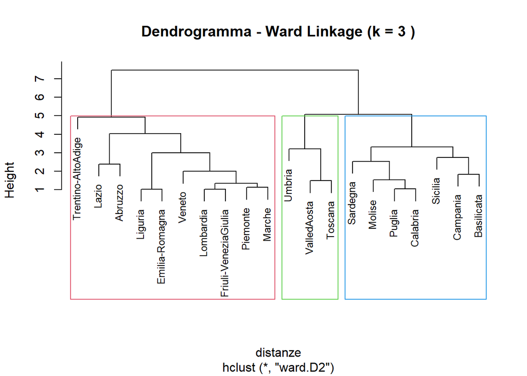

```r
# Utilizzo il metodo Ward (scelto al punto c)
hc_ward <- hclust(distanze, method = "ward.D2")

# Scelgo il numero di cluster (ad esempio 3)
k <- 3
cluster_ward <- cutree(hc_ward, k = k)

# Visualizzo il dendrogramma con il taglio
plot(hc_ward, main = paste("Dendrogramma - Ward Linkage (k =", k, ")"), cex = 0.8)
rect.hclust(hc_ward, k = k, border = 2:4)
```

```r
# Tabella dei gruppi
cat("Distribuzione dei cluster (k =", k, "):\n")
```

```
## Distribuzione dei cluster (k = 3 ):
```

```r
print(table(cluster_ward))
```

```
## cluster_ward
##  1  2  3
## 10  3  7
```

```r
# Composizione dei cluster
cat("\nComposizione dei cluster:\n")
```

```
##
## Composizione dei cluster:
```

```r
for(i in 1:k) {
  cat("Cluster", i, ":", paste(names(cluster_ward[cluster_ward == i]), collapse = ", "), "\n")
}
```

```
## Cluster 1 : Piemonte, Lombardia, Trentino-AltoAdige, Veneto, Friuli-VeneziaGiulia, Liguria, Emilia-Romagna, Marche, Lazio, Abruzzo
## Cluster 2 : ValledAosta, Toscana, Umbria
## Cluster 3 : Molise, Campania, Puglia, Basilicata, Calabria, Sicilia, Sardegna
```

```r
# Valuto clustering con k = 2 e k = 4
cluster_ward_k2 <- cutree(hc_ward, k = 2)
cluster_ward_k4 <- cutree(hc_ward, k = 4)

cat("\n--- Confronto con k = 2 ---\n")
```

```
##
## --- Confronto con k = 2 ---
```

```r
print(table(cluster_ward_k2))
```

```
## cluster_ward_k2
##  1  2
## 10 10
```

```r
cat("Cluster 1:", paste(names(cluster_ward_k2[cluster_ward_k2 == 1]), collapse = ", "), "\n")
```

```
## Cluster 1: Piemonte, Lombardia, Trentino-AltoAdige, Veneto, Friuli-VeneziaGiulia, Liguria, Emilia-Romagna, Marche, Lazio, Abruzzo
```

```r
cat("Cluster 2:", paste(names(cluster_ward_k2[cluster_ward_k2 == 2]), collapse = ", "), "\n")
```

```
## Cluster 2: ValledAosta, Toscana, Umbria, Molise, Campania, Puglia, Basilicata, Calabria, Sicilia, Sardegna
```

```r
cat("\n--- Confronto con k = 4 ---\n")
```

```
##
## --- Confronto con k = 4 ---
```

```r
print(table(cluster_ward_k4))
```

```
## cluster_ward_k4
## 1 2 3 4
## 9 3 1 7
```

```r
for(i in 1:4) {
  cat("Cluster", i, ":", paste(names(cluster_ward_k4[cluster_ward_k4 == i]), collapse = ", "), "\n")
}
```

```
## Cluster 1 : Piemonte, Lombardia, Veneto, Friuli-VeneziaGiulia, Liguria, Emilia-Romagna, Marche, Lazio, Abruzzo
## Cluster 2 : ValledAosta, Toscana, Umbria
## Cluster 3 : Trentino-AltoAdige
## Cluster 4 : Molise, Campania, Puglia, Basilicata, Calabria, Sicilia, Sardegna
```